# Lab 2 - Stats 503

## Functional programming

Download from Canvas the data file “citycrime.txt”, which shows crime rates per 100,000 people on some US cities.

```r
data_crime = read.table("citycrime.txt", header = TRUE)
```

The functions `sapply`, `lapply`, `apply` and `vapply` can apply a function to each element of an object, but the output and syntax is different. These functions are called *functionals*.

```r
colMeans(data_crime)
sapply(data_crime, mean)
lapply(data_crime, mean)
apply(data_crime, 2, mean)
vapply(data_crime, mean, double(1))
```

Examples with user-defined functions to calculate descriptive statistics.

```r
summary_stats = function(x) {
  return(c(mean = mean(x),
              sd = sd(x),
              max = max(x),
              min = min(x),
              med = median(x)))
}

crime_stats = lapply(data_crime, summary_stats)
```

Calculate the cities with higher crime rates.

```r
cities = rownames(data_crime)

max_city = function(x) {
  cities[which.max(x)]
}
sapply(data_crime, max_city)
```

```
##        Murder          Rape       Robbery       Assault      Burglary
## "New-Orleans" "Minneapolis"      "Newark"       "Tampa"    "St-Louis"
##       Larceny           MVT
##       "Miami"       "Tampa"
```

It is very easy to implement parallel programming using functionals.

```r
library(parallel)
wait = function(x) {
   mean(x)
   Sys.sleep(20)
}
num_cores = detectCores() - 1
cl = makeCluster(num_cores)
parLapply(cl, data_crime, wait)
stopCluster(cl)
```

The `Map` function is similar to `lapply` but it apply the function to the elements of multiple arguments. An example to calculate a weighted mean.

```r
cost_per_city = replicate(7, runif(length(cities)), simplify = FALSE)
Map(weighted.mean, data_crime, cost_per_city)
```

`Reduce` succesively combines the elements of a a vector. `Filter` applies a logical function to the elements of a list and returns those that satisfy the condition. There are more functionals for different purposes (`Position`, `Find`, etc.).

```r
top10_cities = lapply(data_crime, function(x) cities[order(x, decreasing = T)[1:10]])

intersect(intersect(intersect(top10_cities$Murder, top10_cities$Rape), top10_cities$Robbery), top10_cities$Assault) #... and so on
```

```
## [1] "Atlanta"
```

```r
Reduce(intersect, top10_cities)
```

```
## [1] "Atlanta"
```

```r
Filter(function(x) "Detroit" %in% x, top10_cities)
```

```
## $Murder
##  [1] "New-Orleans" "Washingt"    "St-Louis"    "Detroit"     "Burmingham"
##  [6] "Atlanta"     "Baltimore"   "Oakland"     "Newark"      "Chicago"
##
## $Rape
##  [1] "Minneapolis" "Cleveland"   "Oklahoma"    "Kansas-City" "Memphis"
##  [6] "Detroit"     "Toledo"      "Columbus"    "Cicinnati"   "Atlanta"
##
## $Robbery
##  [1] "Newark"    "St-Louis"  "Miami"     "Baltimore" "Atlanta"
##  [6] "Detroit"   "Chicago"   "Tampa"     "Washingt"  "Oakland"
##
## $MVT
##  [1] "Tampa"      "Fresno"     "Newark"     "Detroit"    "Miami"
##  [6] "St-Louis"   "Sacramento" "Atlanta"    "Portland"   "Boston"
```

### Reshaping a dataset

There are two formats that a dataset can be presented: long and wide. The functions `melt` and `dcast` can modify from one format to another.

```r
library(reshape2)
data_crime_city = data.frame(data_crime, City = rownames(data_crime))
head(data_crime_city)
```

```
##           Murder Rape Robbery Assault Burglary Larceny    MVT      City
## New-York    21.3 36.3   988.8   814.5   1204.6  2859.9 1300.7  New-York
## LA          23.8 43.8   868.0  1123.4   1226.2  3120.5 1434.3        LA
## Chicago     33.1 40.0  1210.5  1440.9   1563.6  4323.4 1427.9   Chicago
## Houston     21.3 53.0   567.7   665.5   1451.5  3239.2 1287.2   Houston
## Philly      25.9 46.2   814.2   436.2    903.9  2588.3 1620.0    Philly
## San-Diego    9.7 34.5   329.0   704.8   1102.8  3012.0 1371.8 San-Diego
```

```r
long_data_crime = melt(data_crime_city, id.vars = "City")
head(long_data_crime)
```

```
##        City variable value
## 1  New-York   Murder  21.3
## 2        LA   Murder  23.8
## 3   Chicago   Murder  33.1
## 4   Houston   Murder  21.3
## 5    Philly   Murder  25.9
## 6 San-Diego   Murder   9.7
```

```r
wide_data_crime = dcast(long_data_crime, City ~ variable)
head(wide_data_crime)
```

```
##        City Murder  Rape Robbery Assault Burglary Larceny    MVT
## 1     Akron   10.2  86.6   360.5   503.4   1350.4  3879.9  911.8
## 2   Anaheim    8.6  32.3   406.2   500.9   1175.6  3201.7 1229.4
## 3 Anchorage    8.7  78.1   287.4   602.8    897.2  4619.0  863.7
## 4 Arlington    6.3  50.2   228.1   567.4   1210.1  4325.1  865.9
## 5   Atlanta   46.4 102.6  1299.4  2122.5   2951.3  7511.6 2084.6
## 6    Aurora    5.9  58.1   246.4  1137.5   1193.7  4667.9  504.3
```

### Functionals with data frames

The library `plyr` contains functions to perform functional programming. In particular, it is useful to manipulate data frames.

```r
library(plyr)
summarize(data_crime, mean_murder = mean(Murder), mean_robbery = mean(Robbery))
transform(data_crime, murder_square = Murder^2, mean_robbery = mean(Robbery))
```

The function `ddply` is similar to `apply`, but it takes as input and output a data.frame.

```r
ddply(long_data_crime, c("City"), function(df) mean(df$value))
ddply(long_data_crime, c("City"), summarize, mean_city =mean(value), sd_city = sd(value))
```

## Visualization using ggplot

The base plotting functions in R are useful to produce simple outputs, but as the level of difficulty in the plot progresses, they can become difficult to modify. The library `ggplot2` offers a plotting system with substantial capabilities and nicer graphics than the base plotting functions.

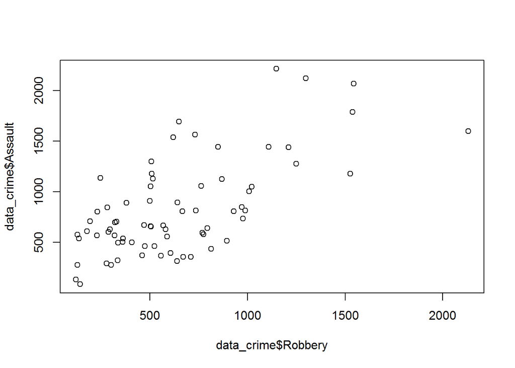

```r
plot(x = data_crime$Robbery, y = data_crime$Assault)
```

The function `qplot` (quick plot) is an equivalent to `plot`. Useful to create simple plots, but it has a limited functionality.

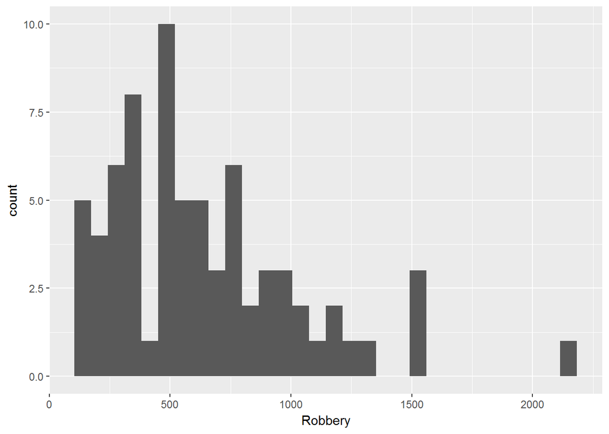

```r
library(ggplot2)
qplot(x=Robbery, data = data_crime, geom="histogram")
```

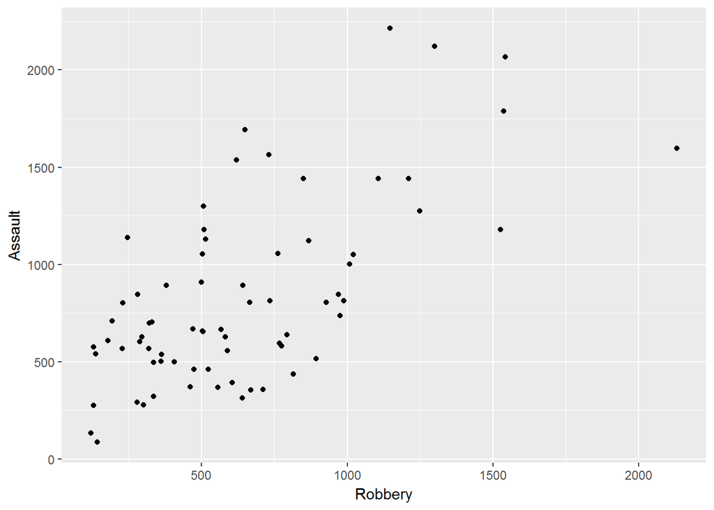

```r
qplot(x = Robbery, y = Assault, data = data_crime)
```

The `ggplot()` is the standard way to create plots.

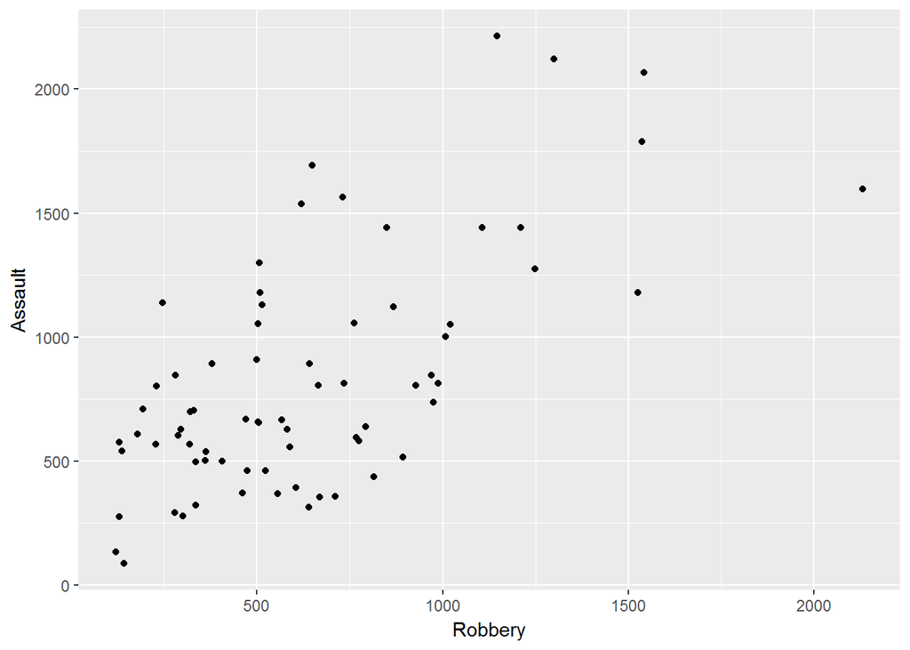

```r
crime_plot = ggplot(data_crime, aes(x = Robbery, y = Assault))
crime_plot + geom_point()
```

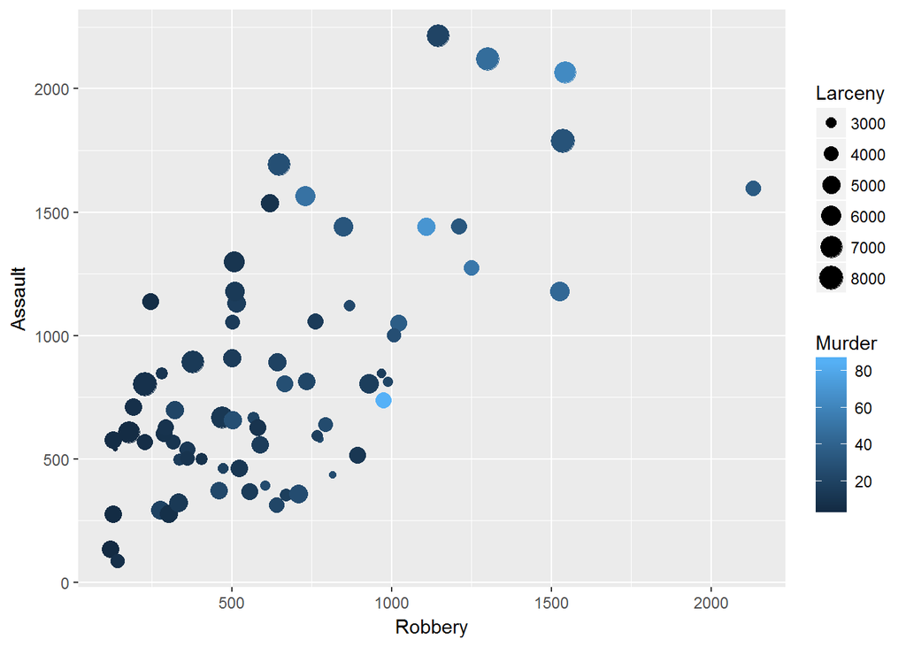

```r
crime_plot + geom_point(aes(color = Murder, size = Larceny))
```

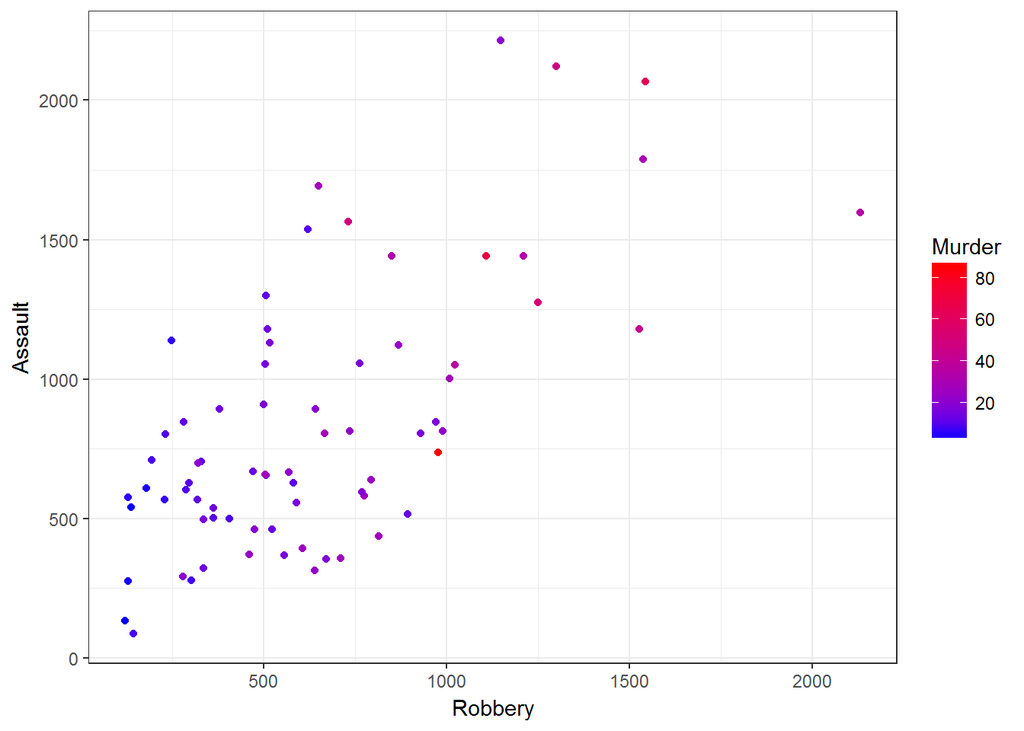

```r
crime_plot + geom_point(aes(color = Murder)) +
  scale_colour_gradient(high = "red", low = "blue") + theme_bw()
```

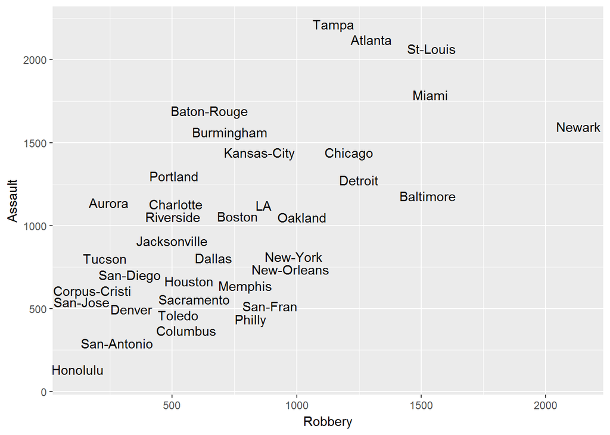

```r
crime_plot + geom_text(aes(label=rownames(data_crime)), check_overlap = TRUE)
```

Sometimes it is useful to create 3D plots to visualize multivariate data. The library `plotly` can do so.

```r
#install.packages("plotly")
library(plotly)
p = plot_ly(data_crime, x = ~Robbery, y = ~Assault, z = ~Murder)
p
```

[interactive chart not shown]

Pairs plots are useful to visualize multiple variables at the same time. The base function is `pairs`, but here is an example with ggplot.

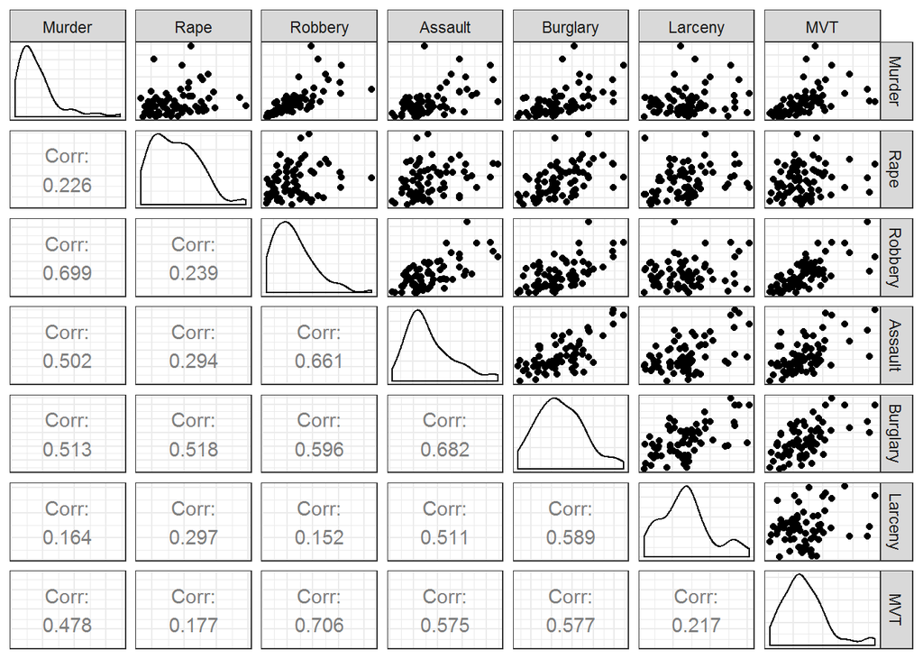

```r
library(GGally)
crime_pairs = ggpairs(data_crime,axisLabels = "none",
        upper = list(continuous = "points", combo = "dot"),
        lower = list(continuous = "cor", combo = "dot"),
        diag = list(continuous = "densityDiag")) +
  theme_bw()
crime_pairs
```

Ggplot easily allows to visualize multiple time series in the same plot. For this, it is necessary to convert the data first to a long format using `melt`.

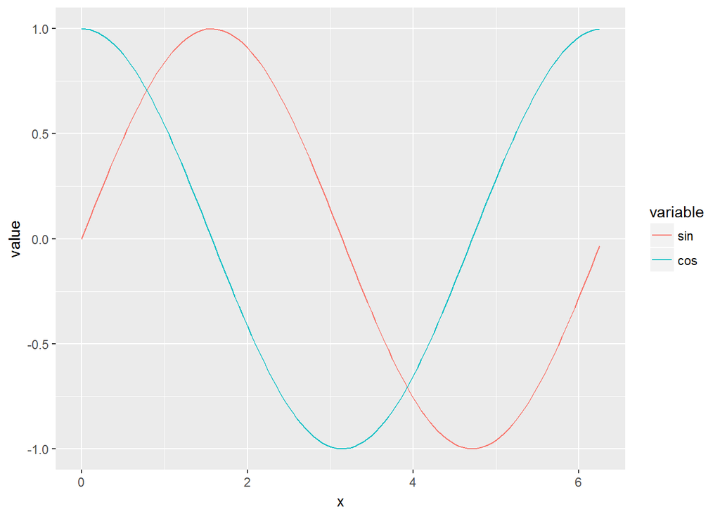

```r
trigon_data = data.frame(lapply(c(sin, cos), function(f) f(seq(0, 2*pi,0.05))), x= seq(0, 2*pi,0.05))
colnames(trigon_data) = c("sin", "cos", "x")
trigon_data_long = melt(trigon_data, id.vars = "x")
ggplot(trigon_data_long, aes(x=x, y=value,colour=variable, group = variable)) + geom_line()
```

Finally, R has functions that allow to save a plot to a file. Different extensions are allowed, here is an example with `pdf`.

```r
pdf("crime_ggpairs.pdf")
crime_pairs
dev.off()
```

## Solutions

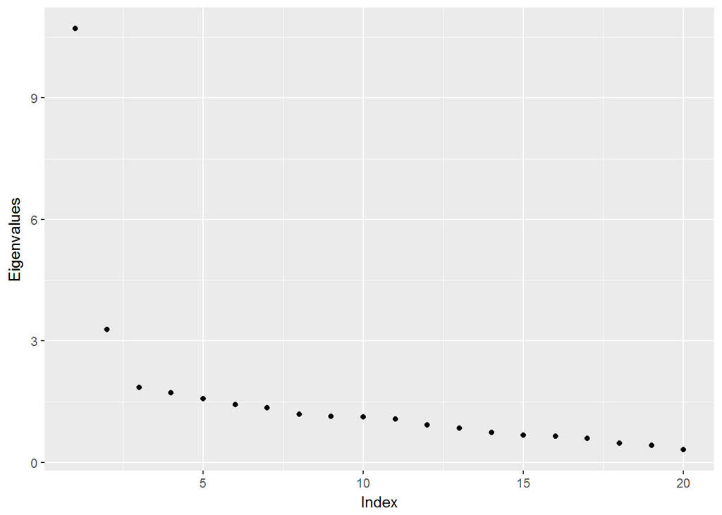

```r
p = 20
n = 100
X = sweep(matrix(rnorm(n*p),ncol = p), 2, c(3,2,rep(1,p-2)), "*")
eigenvalues = eigen(cov(X))$values
qplot(y=eigenvalues, xlab="Index", ylab="Eigenvalues")
```

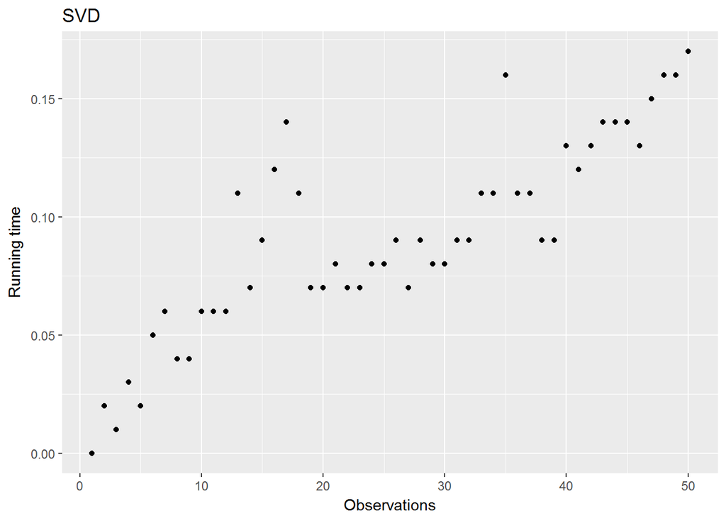

```r
generate_data = function(n, p) {
  X = sweep(matrix(rnorm(n*p),ncol = p), 2, c(3,2,rep(1,p-2)), "*")
}

compute_svd = function(X) {
  start = proc.time()
  X = scale(X, center = TRUE, scale = FALSE)
  eigenvalues = svd(X)$d^2/(nrow(X)-1)
  end = proc.time()
  return(end[3] - start[3])
}

data_obs = lapply(seq(100, 5000, 100), generate_data, p = 100)
svd_times = sapply(data_obs, compute_svd)
qplot(y = svd_times, main = "SVD", xlab = "Observations", ylab = "Running time")
```

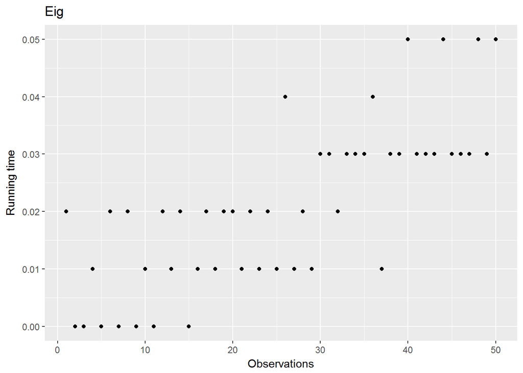

```r
compute_eig = function(X) {
  start = proc.time()
  eigenvalues = eigen(cov(X))$values
  end = proc.time()
  return(end[3] - start[3])
}
eig_times = sapply(data_obs, compute_eig)
qplot(y = eig_times, main = "Eig", xlab = "Observations", ylab = "Running time")
```

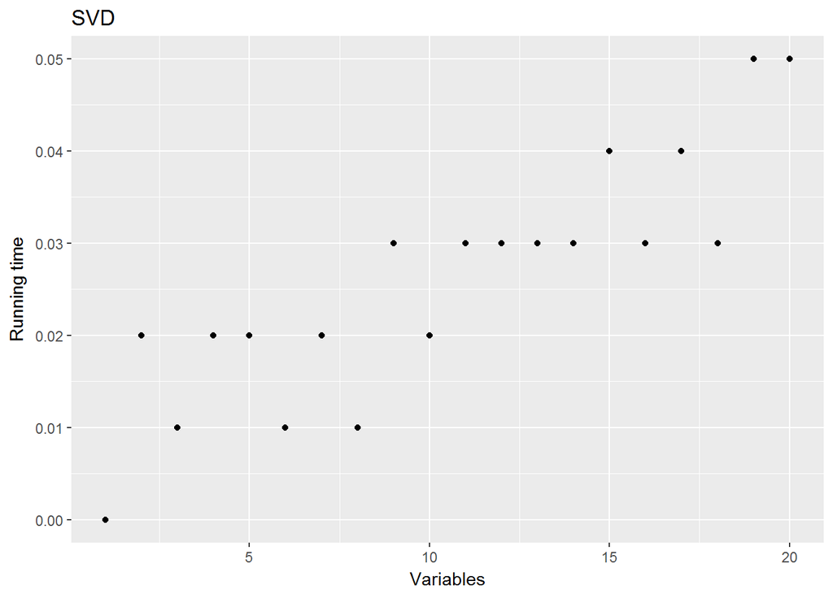

```r
data_var = lapply(seq(100, 2000, 100), generate_data, n = 100)
svd_times = sapply(data_var, compute_svd)
qplot(y = svd_times, main = "SVD", xlab = "Variables", ylab = "Running time")
```

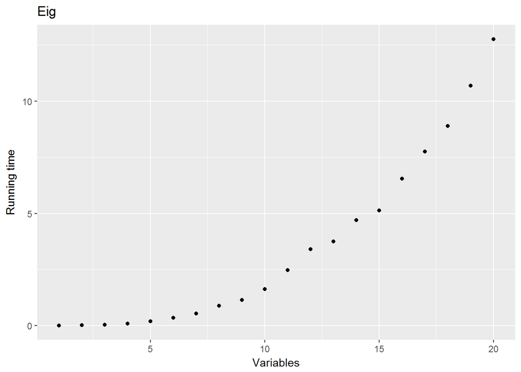

```r
eig_times = sapply(data_var, compute_eig)
qplot(y = eig_times, main = "Eig", xlab = "Variables", ylab = "Running time")
```